# Rat_Growth_Mixed_ANOVA

Micole Ann Castronuevo

2026-11-22

# 1. Introduction and Research Objectives

## Introduction

This study examines the effects of different treatments on the body weight of rats across five measurement occasions, from Week 0 to Week 4. The treatments include Control, Thiouracil, and Thyroxin.

A mixed-design repeated measures ANOVA was used to determine whether body weight changes over time differed among the three treatment groups.

## Research Objectives

The study aims to:

1. Determine whether treatment has a significant effect on rat body weight.
2. Determine whether measurement occasion has a significant effect on rat body weight.
3. Examine whether the effect of treatment on body weight depends on the measurement occasion.
4. Identify differences between treatment groups and measurement occasions through post hoc analyses.

# 2. Data Preparation

## Dataset Description

The dataset contains body weight measurements from 27 rats across five measurement occasions, resulting in 135 observations.

The variables include: - `id`: Unique identifier for each rat. - `trt`: Treatment group (Control, Thiouracil, and Thyroxin). - `time`: Measurement occasion (Week 0 to Week 4). - `y`: Body weight measured in grams.

## Data Importation and Preparation

```r
#install.packages(c("nlmm"))
#install.packages(c("tidyverse","rstatix","ggpubr"))
# in # as package is already installed

library(nlmm)
library(tidyverse)
library(rstatix)
library(ggpubr)

data("rats", package = "nlmm")

rats <- rats %>%
  mutate(
    id = factor(id),
    trt = factor(
      trt,
      levels = c(1,2,3),
      labels = c("Control","Thiouracil","Thyroxin")
    ),
    time = factor(
      time,
      levels = 0:4,
      labels = c(
        "Week 0", "Week 1", "Week 2",
        "Week 3", "Week 4"
      )
    )
  )

str(rats)
```

```
## 'data.frame':    135 obs. of  4 variables:
##  $ id  : Factor w/ 27 levels "1","2","3","4",..: 1 2 3 4 5 6 7 8 9 10 ...
##  $ time: Factor w/ 5 levels "Week 0","Week 1",..: 1 1 1 1 1 1 1 1 1 1 ...
##  $ trt : Factor w/ 3 levels "Control","Thiouracil",..: 1 1 1 1 1 1 1 1 1 1 ...
##  $ y   : int  57 60 52 49 56 46 51 63 49 57 ...
```

```r
dim(rats)
```

```
## [1] 135   4
```

```r
head(rats)
```

```
##   id   time     trt  y
## 1  1 Week 0 Control 57
## 2  2 Week 0 Control 60
## 3  3 Week 0 Control 52
## 4  4 Week 0 Control 49
## 5  5 Week 0 Control 56
## 6  6 Week 0 Control 46
```

```r
table(rats$trt)
```

```
##
##    Control Thiouracil   Thyroxin
##         50         50         35
```

# Identify the dependent variable, between-subjects factor, within-subjects factor, and experimental unit (subject).

Dependent Variable: Body weight (y), measured continuously in grams.

Between-Subjects Factor: Treatment group (trt), consisting of three independent conditions: Control, Thiouracil, and Thyroxin.

Within-Subjects Factor: Measurement occasion (time), consisting of five repeated time points: Week 0 (Baseline), Week 1, Week 2, Week 3, and Week 4.

Experimental Unit (Subject): Each individual rat (id), with a total of 27 subjects across 135 observations (10 rats in Control, 10 rats in Thiouracil, and 7 rats in Thyroxin).

# Why is the rats dataset already in long format? Explain why the subject identifier is necessary when conducting mixed-design repeated measures ANOVA.

The rats dataset is already in long format because each row represents one observation of a rat under a specific condition or measurement period. Instead of having separate columns for each repeated measurement, the dataset organizes the observations into rows, with variables identifying the subject, treatment or condition, and measured outcome.

The subject identifier (e.g., Rat 1, Rat 2, Rat 3) is necessary in a mixed-design repeated measures ANOVA because it allows R Studio to recognize which observations come from the same rat. This is important because repeated measurements from the same subject are related and should not be treated as independent observations. The subject identifier also allows the analysis to account for individual differences between rats and correctly distinguish within-subject effects from between-subject effects.

# 3. Descriptive Statistics and Visualization

```r
## Descriptive Statistics

rats%>%
  group_by(trt,time) %>%
  get_summary_stats(y,type = "mean_sd")
```

```
## # A tibble: 15 × 6
##    time   trt        variable     n  mean    sd
##    <fct>  <fct>      <fct>    <dbl> <dbl> <dbl>
##  1 Week 0 Control    y           10  54    5.44
##  2 Week 1 Control    y           10  78.5  9.64
##  3 Week 2 Control    y           10 106    9.92
##  4 Week 3 Control    y           10 130.  12.6
##  5 Week 4 Control    y           10 161.  15.2
##  6 Week 0 Thiouracil y           10  54.7  4.69
##  7 Week 1 Thiouracil y           10  76.3  7.92
##  8 Week 2 Thiouracil y           10  95.8  8.50
##  9 Week 3 Thiouracil y           10 108.   9.75
## 10 Week 4 Thiouracil y           10 124   11.3
## 11 Week 0 Thyroxin   y            7  55.6  2.99
## 12 Week 1 Thyroxin   y            7  75.9  6.44
## 13 Week 2 Thyroxin   y            7 105.  11.1
## 14 Week 3 Thyroxin   y            7 133.  17.0
## 15 Week 4 Thyroxin   y            7 163.  21.5
```

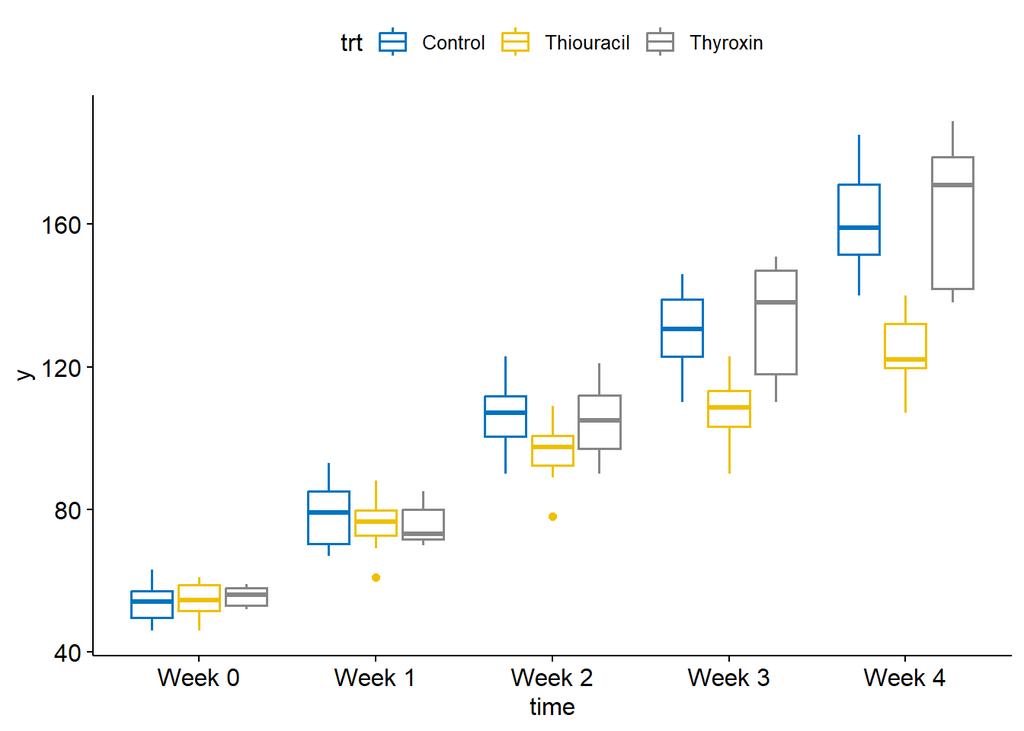

```r
## Data Visualization

ggboxplot(
  rats,
  x = "time",
  y = "y",
  color = "trt",
  palette = "jco"
)
```

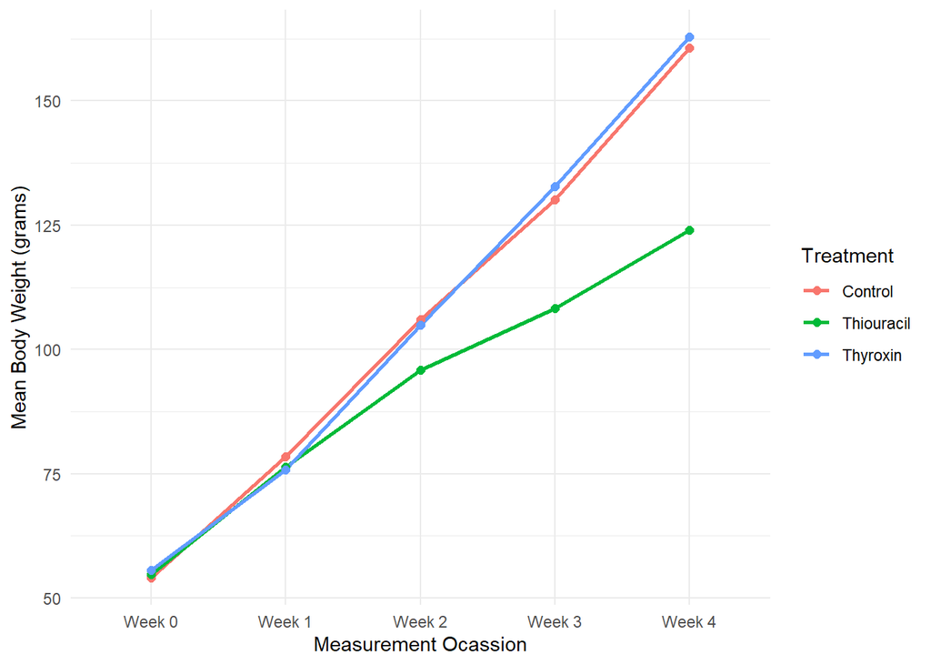

```r
rats%>%
  group_by(trt,time) %>%
  summarise(
    mean_weight = mean(y),
    .groups = "drop"
  ) %>%
  ggplot(
    aes(
      x = time,
      y = mean_weight,
      color = trt,
      group = trt
    )
  ) +
  geom_line(linewidth = 1) +
  geom_point(size = 2) +
  labs(
    x = "Measurement Ocassion",
    y = "Mean Body Weight (grams)",
    color = "Treatment"
  ) +
  theme_minimal()
```